# Forecasting

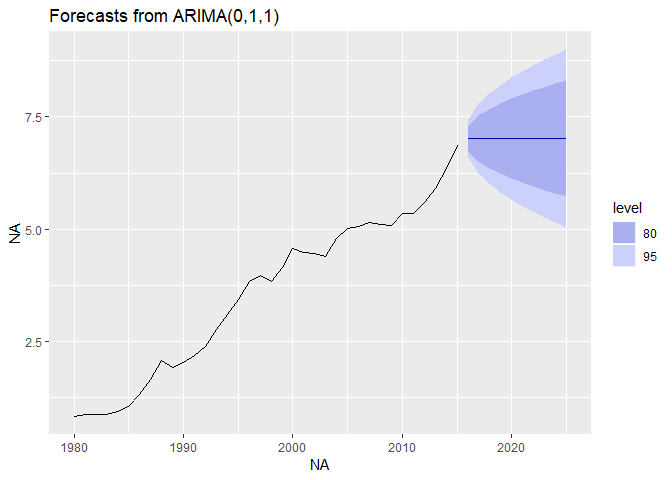

```r
# Plot forecasts from an ARIMA(0,1,1) model with no drift
austa %>% Arima(order = c(0,1,1), include.constant = FALSE) %>% forecast() %>% autoplot()
```

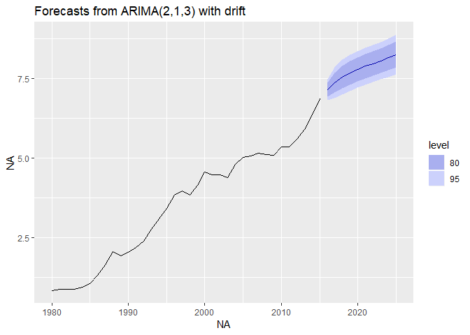

```r
# Plot forecasts from an ARIMA(2,1,3) model with drift
austa %>% Arima(order=c(2,1,3), include.constant=TRUE) %>% forecast() %>% autoplot()
```

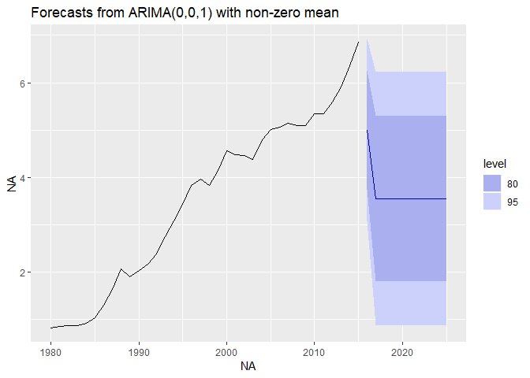

```r
# Plot forecasts from an ARIMA(0,0,1) model with a constant
austa %>% Arima(order=c(0,0,1), include.constant=TRUE) %>% forecast() %>% autoplot()
```

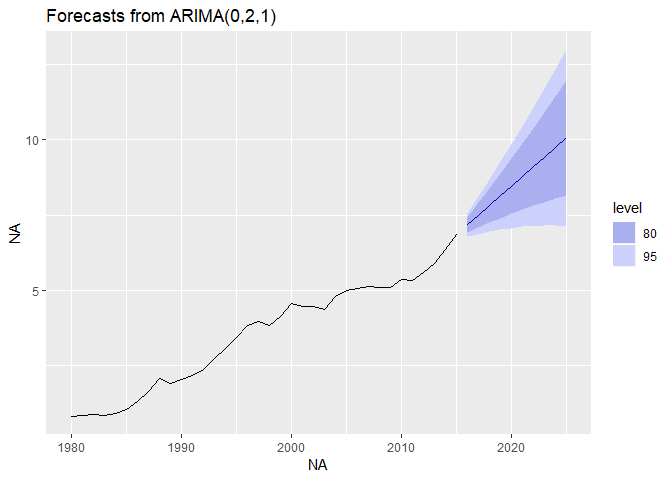

```r
# Plot forecasts from an ARIMA(0,2,1) model with no constant
austa %>% Arima(order=c(0,2,1), include.constant=FALSE) %>% forecast() %>% autoplot()
```

The AICc statistic is useful for selecting between models in the same class. For example, you can use it to select an ETS model or to select an ARIMA model. However, you cannot use it to compare ETS and ARIMA models because they are in different model classes. Instead, you can use time series cross-validation to compare an ARIMA model and an ETS model on the austa data. Because tsCV() requires functions that return forecast objects, you will set up some simple functions that fit the models and return the forecasts. The arguments of tsCV() are a time series, forecast function, and forecast horizon h.

```r
# Set up forecast functions for ETS and ARIMA models
fets <- function(x, h) {
  forecast(ets(x), h = h)
}
farima <- function(x, h) {
  forecast(auto.arima(x), h = h)
}

# Compute CV errors for ETS as e1
e1 <- tsCV(austa, fets, 1)

# Compute CV errors for ARIMA as e2
e2 <- tsCV(austa, farima, 1)

# Find MSE of each model class
mean(e1^2, na.rm=TRUE)
```

```
## [1] 0.05623684
```

```r
mean(e2^2, na.rm=TRUE)
```

```
## [1] 0.04336277
```

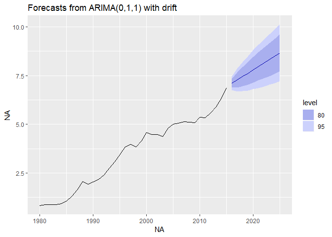

```r
# Plot 10-year forecasts using the best model class
austa %>% farima(h=10) %>% autoplot()
```

### Seasonal ARIMA models

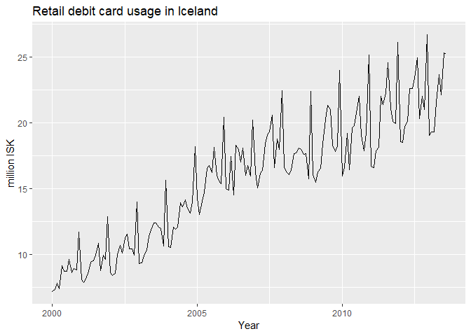

```r
# Seasonal arima with auto.arima()
autoplot(debitcards) +
  xlab("Year") +
  ylab("million ISK") +
  ggtitle("Retail debit card usage in Iceland")
```

```r
# Increasing variation -> Box-Cox
lmd <- BoxCox.lambda(debitcards)
# Use auto.arima to fit seasonal model
fit <- auto.arima(debitcards, lambda = lmd)
fit
```

```
## Series: debitcards
## ARIMA(0,1,2)(0,1,1)[12]
## Box Cox transformation: lambda= 0.09078485
##
## Coefficients:
##           ma1     ma2     sma1
##       -0.8221  0.2106  -0.8311
## s.e.   0.0854  0.0948   0.1136
##
## sigma^2 estimated as 0.003878:  log likelihood=199.12
## AIC=-390.25   AICc=-389.97   BIC=-378.18
```

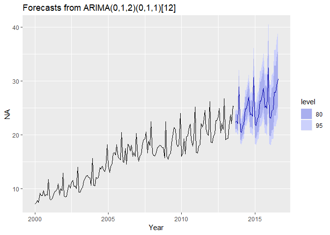

```r
# Forecasting and plotting
fit %>%
  forecast(h =36) %>%
  autoplot() + xlab("Year")
```

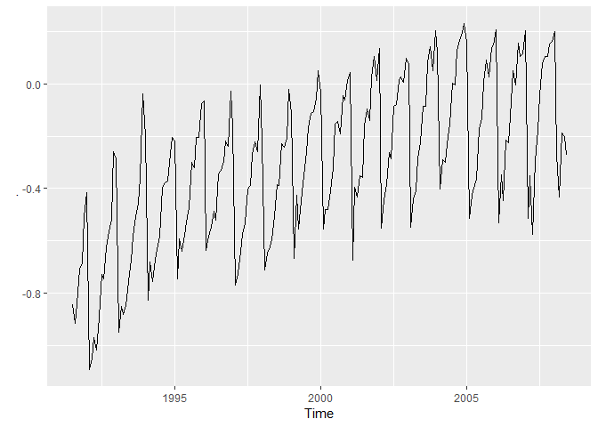

```r
### h02 data ###
# Check that the logged h02 data have stable variance
h02 %>% log() %>% autoplot()
```

```r
# Fit a seasonal ARIMA model to h02 with lambda = 0
fit <- auto.arima(h02, lambda=0)

# Summarize the fitted model
summary(fit)
```

```
## Series: h02
## ARIMA(2,1,1)(0,1,2)[12]
## Box Cox transformation: lambda= 0
##
## Coefficients:
##           ar1      ar2     ma1     sma1     sma2
##       -1.1358  -0.5753  0.3683  -0.5318  -0.1817
## s.e.   0.1608   0.0965  0.1884   0.0838   0.0881
##
## sigma^2 estimated as 0.004278:  log likelihood=248.25
## AIC=-484.51   AICc=-484.05   BIC=-465
##
## Training set error measures:
##                        ME      RMSE        MAE        MPE     MAPE
## Training set -0.003931805 0.0501571 0.03629816 -0.5323365 4.611253
##                   MASE         ACF1
## Training set 0.5987988 -0.003740267
```

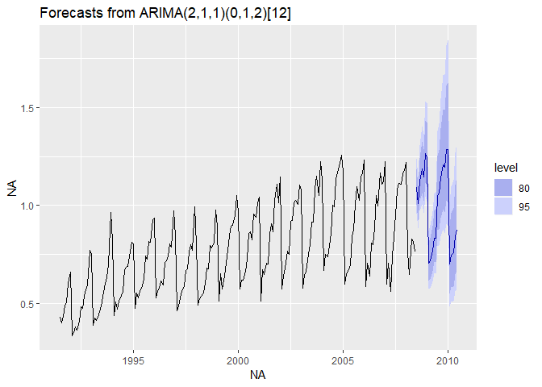

```r
# Record the amount of lag-1 differencing and seasonal differencing used
d <- 1
D <- 1

# Plot 2-year forecasts
fit %>% forecast(h=24) %>% autoplot()
```

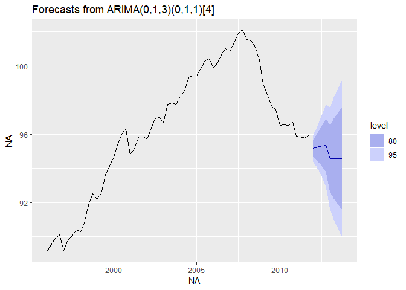

```r
### euretail ###
# Find an ARIMA model for euretail
fit1 <- auto.arima(euretail)

# Don't use a stepwise search
fit2 <- auto.arima(euretail, stepwise = FALSE)

# AICc of better model
AICc <- 68.39

# Compute 2-year forecasts from better model
fit2 %>% forecast(h=8) %>% autoplot()
```

Comparing auto.arima() and ets() on seasonal data.

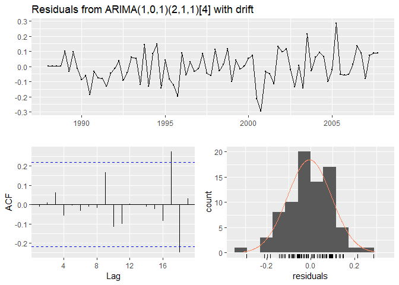

```
##
##  Ljung-Box test
##
## data:  Residuals from ARIMA(1,0,1)(2,1,1)[4] with drift
## Q* = 3.3058, df = 3, p-value = 0.3468
##
## Model df: 6.   Total lags used: 9
```

```r
# Use 20 years of the qcement data beginning in 1988
train <- window(qcement, start = c(1988,1), end = c(2007,4))

# Fit an ARIMA and an ETS model to the training data
fit1 <- auto.arima(train)
fit2 <- ets(train)

# Check that both models have white noise residuals
checkresiduals(fit1)
```

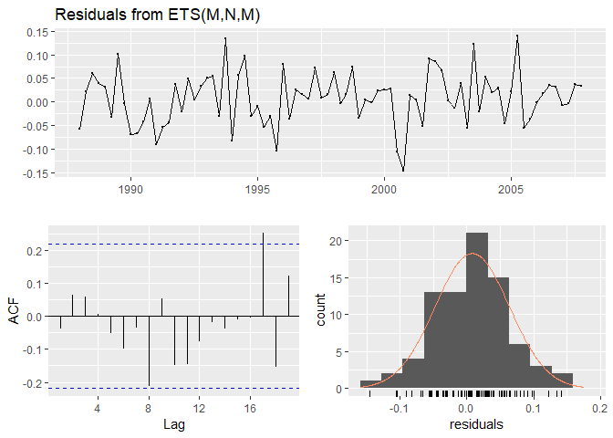

```
##
##  Ljung-Box test
##
## data:  Residuals from ETS(M,N,M)
## Q* = 6.3457, df = 3, p-value = 0.09595
##
## Model df: 6.   Total lags used: 9
```

```r
checkresiduals(fit2)
```

```r
# Produce forecasts for each model
fc1 <- forecast(fit1, h = 25)
fc2 <- forecast(fit2, h = 25)

# Use accuracy() to find better model based on RMSE
accuracy(fc1, qcement)
```

```
##                        ME      RMSE        MAE        MPE     MAPE
## Training set -0.006205705 0.1001195 0.07988903 -0.6704455 4.372443
## Test set     -0.158835253 0.1996098 0.16882205 -7.3332836 7.719241
##                   MASE        ACF1 Theil's U
## Training set 0.5458078 -0.01133907        NA
## Test set     1.1534049  0.29170452 0.7282225
```

```r
accuracy(fc2, qcement)
```

```
##                       ME      RMSE        MAE        MPE     MAPE
## Training set  0.01406512 0.1022079 0.07958478  0.4938163 4.371823
## Test set     -0.13495515 0.1838791 0.15395141 -6.2508975 6.986077
##                   MASE        ACF1 Theil's U
## Training set 0.5437292 -0.03346295        NA
## Test set     1.0518075  0.53438371  0.680556
```

```r
bettermodel <- fit2
```